# 5 - Different kernels

```python
import musicntd.scripts.hide_code as hide
```

This notebook aims at studying 3 different kernels for the convolution measure.

Note, as a prerequisite, that the diagonal of all our kernels is zero. Indeed, we consider that the diagonal of autosimilarity matrices doesn't hold structural information, and that considering it is counter-productive.

More details about the design of these kernels can be found in the Notebook "Appendix - Focus on the segmentation algorithm".

# Full kernel

This kernel is a square matrix only composed of 0 and 1. It is equal to 0 on the diagonal, and to 1 elsewhere.

It looks like:

[figure not shown]

(or, in a matrix form: $\left[ \begin{matrix} 0 & 1 & 1 & 1& 1 & 1 & 1 & 1\\ 1 & 0 & 1 & 1& 1 & 1 & 1 & 1\\ 1 & 1 & 0 & 1& 1 & 1 & 1 & 1\\ 1 & 1 & 1 & 0 & 1 & 1 & 1 & 1\\ 1 & 1 & 1 & 1 & 0 & 1 & 1 & 1\\ 1 & 1 & 1 & 1 & 1 & 0 & 1 & 1\\ 1 & 1 & 1& 1 & 1 & 1 & 0 & 1\\ 1 & 1 & 1& 1 & 1 & 1 & 1 & 0\\ \end{matrix} \right]$ (of size 8 here)).

Mathematically, for a segment ($b_1, b_2$), the associated cost will be $c_{b_1,b_2} = \frac{1}{b_2 - b_1 + 1}\sum_{i,j = 0, i \ne j}^{n - 1} a_{i + b_1, j + b_1}$.

By construction, this kernel catches the similarity everywhere around the diagonal. As high similarity means higher values (and dark zones) in our autosimilarities, the higher this kernel, the more similar is the zone we are studying.

(You should read the "Appendix - Focus on the segmentation algorithm" notebook if you don't understand well how our algorithm work, and why the kernel is important).

## Fixed ranks

Below are segmentation results with different ranks values, but each time fixed over the entire RWC Pop dataset.

Results are computed with tolerance of respectively 0.5 seconds and 3 seconds.

```python
annotations_type = "MIREX10"
ranks_rhythm = [12,16,20,24,28,32,36,40,44,48]
ranks_pattern = [12,16,20,24,28,32,36,40,44,48]
zero_five_full, three_full = hide.compute_ranks_RWC(ranks_rhythm,ranks_pattern, W = "chromas", annotations_type = annotations_type,
                                                  subdivision=96, penalty_weight = 1,penalty_func = "modulo8", convolution_type = "full")
```

|  | 0.5 seconds results | True Positives | False Positives | False Negatives | Precision | Recall | F measure |
| --- | --- | --- | --- | --- | --- | --- | --- |
| Rang Q:12 | Rang H:12 | 7.5400 | 5.5000 | 11.2700 | 0.5806 | 0.4113 | 0.4726 |
|  | Rang H:16 | 7.8500 | 5.4200 | 10.9600 | 0.5933 | 0.4270 | 0.4881 |
|  | Rang H:20 | 7.9500 | 5.3900 | 10.8600 | 0.6017 | 0.4320 | 0.4941 |
|  | Rang H:24 | 8.0000 | 5.3100 | 10.8100 | 0.6029 | 0.4333 | 0.4958 |
|  | Rang H:28 | 8.0500 | 5.3800 | 10.7600 | 0.6024 | 0.4354 | 0.4970 |
|  | Rang H:32 | 7.8000 | 5.7300 | 11.0100 | 0.5764 | 0.4228 | 0.4788 |
|  | Rang H:36 | 8.1800 | 5.1200 | 10.6300 | 0.6118 | 0.4411 | 0.5045 |
|  | Rang H:40 | 8.1400 | 5.4600 | 10.6700 | 0.5999 | 0.4400 | 0.4994 |
|  | Rang H:44 | 8.2200 | 5.3500 | 10.5900 | 0.6041 | 0.4456 | 0.5046 |
|  | Rang H:48 | 8.1600 | 5.3000 | 10.6500 | 0.6052 | 0.4395 | 0.5010 |
| Rang Q:16 | Rang H:12 | 8.3200 | 5.8100 | 10.4900 | 0.5895 | 0.4526 | 0.5026 |
|  | Rang H:16 | 8.7500 | 5.5600 | 10.0600 | 0.6151 | 0.4719 | 0.5256 |
|  | Rang H:20 | 9.1500 | 5.3700 | 9.6600 | 0.6296 | 0.4944 | 0.5451 |
|  | Rang H:24 | 9.1200 | 5.2700 | 9.6900 | 0.6347 | 0.4933 | 0.5477 |
|  | Rang H:28 | 9.0000 | 5.4600 | 9.8100 | 0.6266 | 0.4879 | 0.5403 |
|  | Rang H:32 | 8.8200 | 5.8400 | 9.9900 | 0.6086 | 0.4775 | 0.5274 |
|  | Rang H:36 | 9.1000 | 5.5800 | 9.7100 | 0.6216 | 0.4901 | 0.5407 |
|  | Rang H:40 | 9.2200 | 5.4300 | 9.5900 | 0.6341 | 0.4979 | 0.5500 |
|  | Rang H:44 | 9.2400 | 5.2400 | 9.5700 | 0.6396 | 0.4987 | 0.5533 |
|  | Rang H:48 | 9.1800 | 5.4900 | 9.6300 | 0.6264 | 0.4954 | 0.5459 |
| Rang Q:20 | Rang H:12 | 9.1000 | 5.5600 | 9.7100 | 0.6246 | 0.4916 | 0.5419 |
|  | Rang H:16 | 9.3100 | 5.5300 | 9.5000 | 0.6257 | 0.5020 | 0.5483 |
|  | Rang H:20 | 9.5000 | 5.7600 | 9.3100 | 0.6258 | 0.5110 | 0.5541 |
|  | Rang H:24 | 9.6500 | 5.5100 | 9.1600 | 0.6362 | 0.5192 | 0.5642 |
|  | Rang H:28 | 9.7000 | 5.6100 | 9.1100 | 0.6354 | 0.5228 | 0.5656 |
|  | Rang H:32 | 9.4300 | 5.9500 | 9.3800 | 0.6201 | 0.5082 | 0.5503 |
|  | Rang H:36 | 9.6000 | 5.6400 | 9.2100 | 0.6294 | 0.5185 | 0.5609 |
|  | Rang H:40 | 9.8200 | 5.3600 | 8.9900 | 0.6533 | 0.5297 | 0.5764 |
|  | Rang H:44 | 9.5000 | 5.7400 | 9.3100 | 0.6248 | 0.5128 | 0.5547 |
|  | Rang H:48 | 9.7200 | 5.4600 | 9.0900 | 0.6413 | 0.5221 | 0.5677 |

[output cut: 70 more lines]

|  | 3 seconds results | True Positives | False Positives | False Negatives | Precision | Recall | F measure |
| --- | --- | --- | --- | --- | --- | --- | --- |
| Rang Q:12 | Rang H:12 | 10.0300 | 3.0100 | 8.7800 | 0.7840 | 0.5425 | 0.6296 |
|  | Rang H:16 | 10.1600 | 3.1100 | 8.6500 | 0.7796 | 0.5506 | 0.6341 |
|  | Rang H:20 | 10.1900 | 3.1500 | 8.6200 | 0.7809 | 0.5523 | 0.6356 |
|  | Rang H:24 | 10.2000 | 3.1100 | 8.6100 | 0.7781 | 0.5510 | 0.6344 |
|  | Rang H:28 | 10.2800 | 3.1500 | 8.5300 | 0.7792 | 0.5554 | 0.6378 |
|  | Rang H:32 | 10.2800 | 3.2500 | 8.5300 | 0.7750 | 0.5554 | 0.6355 |
|  | Rang H:36 | 10.2800 | 3.0200 | 8.5300 | 0.7814 | 0.5549 | 0.6387 |
|  | Rang H:40 | 10.2900 | 3.3100 | 8.5200 | 0.7698 | 0.5567 | 0.6357 |
|  | Rang H:44 | 10.4700 | 3.1000 | 8.3400 | 0.7838 | 0.5669 | 0.6470 |
|  | Rang H:48 | 10.3600 | 3.1000 | 8.4500 | 0.7826 | 0.5596 | 0.6419 |
| Rang Q:16 | Rang H:12 | 10.8700 | 3.2600 | 7.9400 | 0.7837 | 0.5881 | 0.6598 |
|  | Rang H:16 | 11.0700 | 3.2400 | 7.7400 | 0.7889 | 0.5961 | 0.6684 |
|  | Rang H:20 | 11.3500 | 3.1700 | 7.4600 | 0.7968 | 0.6126 | 0.6813 |
|  | Rang H:24 | 11.2400 | 3.1500 | 7.5700 | 0.7952 | 0.6075 | 0.6792 |
|  | Rang H:28 | 11.2600 | 3.2000 | 7.5500 | 0.7908 | 0.6090 | 0.6774 |
|  | Rang H:32 | 11.3600 | 3.3000 | 7.4500 | 0.7898 | 0.6110 | 0.6785 |
|  | Rang H:36 | 11.3300 | 3.3500 | 7.4800 | 0.7847 | 0.6094 | 0.6764 |
|  | Rang H:40 | 11.2800 | 3.3700 | 7.5300 | 0.7842 | 0.6073 | 0.6746 |
|  | Rang H:44 | 11.2000 | 3.2800 | 7.6100 | 0.7850 | 0.6027 | 0.6728 |
|  | Rang H:48 | 11.4100 | 3.2600 | 7.4000 | 0.7890 | 0.6146 | 0.6814 |
| Rang Q:20 | Rang H:12 | 11.2400 | 3.4200 | 7.5700 | 0.7815 | 0.6051 | 0.6713 |
|  | Rang H:16 | 11.6200 | 3.2200 | 7.1900 | 0.7979 | 0.6272 | 0.6911 |
|  | Rang H:20 | 11.6600 | 3.6000 | 7.1500 | 0.7806 | 0.6272 | 0.6848 |
|  | Rang H:24 | 11.7100 | 3.4500 | 7.1000 | 0.7850 | 0.6305 | 0.6896 |
|  | Rang H:28 | 11.9000 | 3.4100 | 6.9100 | 0.7902 | 0.6418 | 0.6981 |
|  | Rang H:32 | 11.6700 | 3.7100 | 7.1400 | 0.7712 | 0.6273 | 0.6815 |
|  | Rang H:36 | 11.7900 | 3.4500 | 7.0200 | 0.7855 | 0.6354 | 0.6923 |
|  | Rang H:40 | 11.8100 | 3.3700 | 7.0000 | 0.7917 | 0.6358 | 0.6945 |
|  | Rang H:44 | 11.6200 | 3.6200 | 7.1900 | 0.7738 | 0.6267 | 0.6817 |
|  | Rang H:48 | 11.7800 | 3.4000 | 7.0300 | 0.7894 | 0.6333 | 0.6927 |

[output cut: 70 more lines]

## Oracle ranks

In this condition, we only keep the ranks leading to the highest F measure.

In that sense, it's an optimistic upper bound on metrics.

```python
hide.printmd("**A 0.5 secondes:**")
best_chr_zero_five = hide.best_f_one_score_rank(zero_five_full)
hide.printmd("**A 3 secondes:**")
best_chr_three = hide.best_f_one_score_rank(three_full)
```

**A 0.5 secondes:**

|  | True Positives | False Positives | False Negatives | Precision | Recall | F measure |
| --- | --- | --- | --- | --- | --- | --- |
| Maximizing the f measure on each song: | 12.51 | 3.75 | 6.3 | 0.7719 | 0.6721 | 0.7116 |

**A 3 secondes:**

|  | True Positives | False Positives | False Negatives | Precision | Recall | F measure |
| --- | --- | --- | --- | --- | --- | --- |
| Maximizing the f measure on each song: | 14.3 | 2.09 | 4.51 | 0.8783 | 0.7696 | 0.8143 |

Below is presented the distribution of the optimal ranks in the "oracle ranks" condition, *i.e.* the distribution of the ranks for $H$ and $Q$ which result in the highest F measure for the different songs.

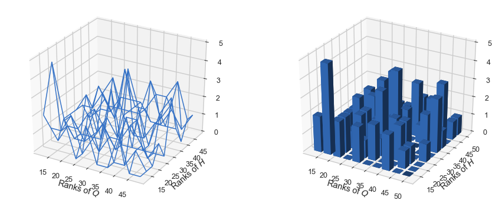

```python
hide.plot_3d_ranks_study(zero_five_full, ranks_rhythm, ranks_pattern)
```

Below is shown the distribution histogram of the F measure obtained with the oracle ranks.

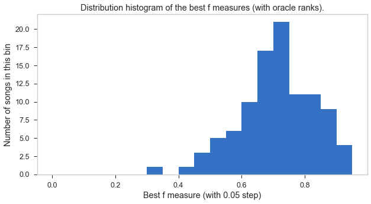

```python
hide.plot_f_mes_histogram(zero_five_full)
```

# 8 bands kernel

This kernel focuses on local similarities in the 8 bars surrounding each bar of the diagonal (4 bars in the future, 4 bars in the past). Concretely, this kernel is a matrix where the only non-zero elements are the 8 closest bands parallel to the diagonal.

It looks like:

[figure not shown]

(or, in a matrix form: $\left[ \begin{matrix} 0 & 1 & 1 & 1& 1 & 0 & 0 & 0\\ 1 & 0 & 1 & 1& 1 & 1 & 0 & 0\\ 1 & 1 & 0 & 1& 1 & 1 & 1 & 0\\ 1 & 1 & 1 & 0 & 1 & 1 & 1 & 1\\ 1 & 1 & 1 & 1 & 0 & 1 & 1 & 1\\ 0 & 1 & 1 & 1 & 1 & 0 & 1 & 1\\ 0 & 0 & 1& 1 & 1 & 1 & 0 & 1\\ 0 & 0 & 0& 1 & 1 & 1 & 1 & 0\\ \end{matrix} \right]$ (of size 8 here)).

Mathematically, for a segment ($b_1, b_2$), the associated cost will be $c_{b_1,b_2} = \frac{1}{b_2 - b_1 + 1}\sum_{i,j = 0, 1 \leq |i - j| \leq 4}^{n - 1} a_{i + b_1, j + b_1}$.

## Fixed ranks

Below are segmentation results with different ranks values, but each time fixed over the entire RWC Pop dataset.

Results are computed with tolerance of respectively 0.5 seconds and 3 seconds.

```python
annotations_type = "MIREX10"
ranks_rhythm = [12,16,20,24,28,32,36,40,44,48]
ranks_pattern = [12,16,20,24,28,32,36,40,44,48]
zero_five_eight, three_eight = hide.compute_ranks_RWC(ranks_rhythm,ranks_pattern, W = "chromas", annotations_type = annotations_type,
                                                  subdivision=96, penalty_weight = 1,penalty_func = "modulo8", convolution_type = "eight_bands")
```

|  | 0.5 seconds results | True Positives | False Positives | False Negatives | Precision | Recall | F measure |
| --- | --- | --- | --- | --- | --- | --- | --- |
| Rang Q:12 | Rang H:12 | 10.3000 | 13.3900 | 8.5100 | 0.4498 | 0.5533 | 0.4900 |
|  | Rang H:16 | 10.8100 | 12.7400 | 8.0000 | 0.4753 | 0.5809 | 0.5163 |
|  | Rang H:20 | 11.3800 | 11.9200 | 7.4300 | 0.5059 | 0.6083 | 0.5455 |
|  | Rang H:24 | 11.0700 | 12.4400 | 7.7400 | 0.4865 | 0.5916 | 0.5271 |
|  | Rang H:28 | 11.1300 | 12.2200 | 7.6800 | 0.4919 | 0.5950 | 0.5315 |
|  | Rang H:32 | 10.6900 | 12.9300 | 8.1200 | 0.4684 | 0.5719 | 0.5083 |
|  | Rang H:36 | 11.1700 | 12.2500 | 7.6400 | 0.4945 | 0.5969 | 0.5340 |
|  | Rang H:40 | 11.3700 | 12.2500 | 7.4400 | 0.5002 | 0.6074 | 0.5416 |
|  | Rang H:44 | 11.3100 | 12.2500 | 7.5000 | 0.4972 | 0.6036 | 0.5382 |
|  | Rang H:48 | 11.1200 | 12.3300 | 7.6900 | 0.4888 | 0.5936 | 0.5294 |
| Rang Q:16 | Rang H:12 | 10.9900 | 12.7400 | 7.8200 | 0.4816 | 0.5930 | 0.5244 |
|  | Rang H:16 | 11.5700 | 11.7400 | 7.2400 | 0.5172 | 0.6173 | 0.5560 |
|  | Rang H:20 | 11.7900 | 11.7900 | 7.0200 | 0.5234 | 0.6325 | 0.5655 |
|  | Rang H:24 | 11.5100 | 12.0200 | 7.3000 | 0.5098 | 0.6211 | 0.5526 |
|  | Rang H:28 | 11.7200 | 11.7900 | 7.0900 | 0.5189 | 0.6268 | 0.5605 |
|  | Rang H:32 | 11.1700 | 12.4300 | 7.6400 | 0.4953 | 0.6009 | 0.5363 |
|  | Rang H:36 | 11.4100 | 12.0700 | 7.4000 | 0.5055 | 0.6091 | 0.5451 |
|  | Rang H:40 | 11.6300 | 11.9200 | 7.1800 | 0.5130 | 0.6238 | 0.5559 |
|  | Rang H:44 | 11.7200 | 11.8000 | 7.0900 | 0.5193 | 0.6263 | 0.5608 |
|  | Rang H:48 | 11.5800 | 11.7600 | 7.2300 | 0.5169 | 0.6190 | 0.5561 |
| Rang Q:20 | Rang H:12 | 11.7700 | 11.9600 | 7.0400 | 0.5160 | 0.6306 | 0.5605 |
|  | Rang H:16 | 11.7700 | 11.7400 | 7.0400 | 0.5194 | 0.6266 | 0.5610 |
|  | Rang H:20 | 12.0000 | 11.3600 | 6.8100 | 0.5355 | 0.6406 | 0.5762 |
|  | Rang H:24 | 12.0600 | 11.4000 | 6.7500 | 0.5366 | 0.6447 | 0.5783 |
|  | Rang H:28 | 11.9300 | 11.3800 | 6.8800 | 0.5338 | 0.6399 | 0.5753 |
|  | Rang H:32 | 11.7800 | 11.7200 | 7.0300 | 0.5272 | 0.6341 | 0.5690 |
|  | Rang H:36 | 11.9300 | 11.3800 | 6.8800 | 0.5365 | 0.6408 | 0.5775 |
|  | Rang H:40 | 12.1200 | 11.1500 | 6.6900 | 0.5441 | 0.6506 | 0.5855 |
|  | Rang H:44 | 11.5900 | 11.8700 | 7.2200 | 0.5195 | 0.6234 | 0.5592 |
|  | Rang H:48 | 11.8400 | 11.5800 | 6.9700 | 0.5296 | 0.6333 | 0.5697 |

[output cut: 70 more lines]

|  | 3 seconds results | True Positives | False Positives | False Negatives | Precision | Recall | F measure |
| --- | --- | --- | --- | --- | --- | --- | --- |
| Rang Q:12 | Rang H:12 | 14.1200 | 9.5700 | 4.6900 | 0.6178 | 0.7543 | 0.6714 |
|  | Rang H:16 | 14.2700 | 9.2800 | 4.5400 | 0.6282 | 0.7621 | 0.6807 |
|  | Rang H:20 | 14.3400 | 8.9600 | 4.4700 | 0.6392 | 0.7659 | 0.6887 |
|  | Rang H:24 | 14.2600 | 9.2500 | 4.5500 | 0.6284 | 0.7614 | 0.6805 |
|  | Rang H:28 | 14.4000 | 8.9500 | 4.4100 | 0.6406 | 0.7692 | 0.6902 |
|  | Rang H:32 | 14.3800 | 9.2400 | 4.4300 | 0.6338 | 0.7671 | 0.6854 |
|  | Rang H:36 | 14.3000 | 9.1200 | 4.5100 | 0.6321 | 0.7642 | 0.6838 |
|  | Rang H:40 | 14.3800 | 9.2400 | 4.4300 | 0.6328 | 0.7687 | 0.6859 |
|  | Rang H:44 | 14.5000 | 9.0600 | 4.3100 | 0.6381 | 0.7742 | 0.6914 |
|  | Rang H:48 | 14.4500 | 9.0000 | 4.3600 | 0.6390 | 0.7729 | 0.6915 |
| Rang Q:16 | Rang H:12 | 14.4800 | 9.2500 | 4.3300 | 0.6366 | 0.7753 | 0.6900 |
|  | Rang H:16 | 14.6000 | 8.7100 | 4.2100 | 0.6524 | 0.7801 | 0.7023 |
|  | Rang H:20 | 14.8800 | 8.7000 | 3.9300 | 0.6587 | 0.7970 | 0.7126 |
|  | Rang H:24 | 14.6800 | 8.8500 | 4.1300 | 0.6509 | 0.7867 | 0.7031 |
|  | Rang H:28 | 14.6700 | 8.8400 | 4.1400 | 0.6479 | 0.7828 | 0.7006 |
|  | Rang H:32 | 14.6200 | 8.9800 | 4.1900 | 0.6478 | 0.7828 | 0.7001 |
|  | Rang H:36 | 14.4000 | 9.0800 | 4.4100 | 0.6401 | 0.7701 | 0.6904 |
|  | Rang H:40 | 14.4300 | 9.1200 | 4.3800 | 0.6367 | 0.7717 | 0.6895 |
|  | Rang H:44 | 14.4800 | 9.0400 | 4.3300 | 0.6426 | 0.7745 | 0.6940 |
|  | Rang H:48 | 14.6100 | 8.7300 | 4.2000 | 0.6528 | 0.7818 | 0.7028 |
| Rang Q:20 | Rang H:12 | 14.8400 | 8.8900 | 3.9700 | 0.6496 | 0.7948 | 0.7064 |
|  | Rang H:16 | 14.8900 | 8.6200 | 3.9200 | 0.6596 | 0.7958 | 0.7127 |
|  | Rang H:20 | 14.8700 | 8.4900 | 3.9400 | 0.6626 | 0.7941 | 0.7141 |
|  | Rang H:24 | 14.8600 | 8.6000 | 3.9500 | 0.6614 | 0.7930 | 0.7125 |
|  | Rang H:28 | 14.7700 | 8.5400 | 4.0400 | 0.6591 | 0.7915 | 0.7114 |
|  | Rang H:32 | 14.6600 | 8.8400 | 4.1500 | 0.6495 | 0.7857 | 0.7029 |
|  | Rang H:36 | 14.7800 | 8.5300 | 4.0300 | 0.6597 | 0.7920 | 0.7119 |
|  | Rang H:40 | 14.9700 | 8.3000 | 3.8400 | 0.6685 | 0.8023 | 0.7211 |
|  | Rang H:44 | 14.6500 | 8.8100 | 4.1600 | 0.6516 | 0.7845 | 0.7031 |
|  | Rang H:48 | 14.8800 | 8.5400 | 3.9300 | 0.6633 | 0.7960 | 0.7150 |

[output cut: 70 more lines]

## Oracle ranks

In this condition, we only keep the ranks leading to the highest F measure.

In that sense, it's an optimistic upper bound on metrics.

```python
hide.printmd("**A 0.5 secondes:**")
best_chr_zero_five = hide.best_f_one_score_rank(zero_five_eight)
hide.printmd("**A 3 secondes:**")
best_chr_three = hide.best_f_one_score_rank(three_eight)
```

**A 0.5 secondes:**

|  | True Positives | False Positives | False Negatives | Precision | Recall | F measure |
| --- | --- | --- | --- | --- | --- | --- |
| Maximizing the f measure on each song: | 14.93 | 7.67 | 3.88 | 0.6847 | 0.7999 | 0.7303 |

**A 3 secondes:**

|  | True Positives | False Positives | False Negatives | Precision | Recall | F measure |
| --- | --- | --- | --- | --- | --- | --- |
| Maximizing the f measure on each song: | 17.07 | 5.04 | 1.74 | 0.7948 | 0.9124 | 0.8414 |

Below is presented the distribution of the optimal ranks in the "oracle ranks" condition, *i.e.* the distribution of the ranks for $H$ and $Q$ which result in the highest F measure for the different songs.

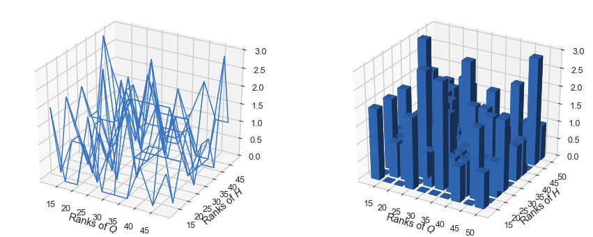

```python
hide.plot_3d_ranks_study(zero_five_eight, ranks_rhythm, ranks_pattern)
```

Below is shown the distribution histogram of the F measure obtained with the oracle ranks.

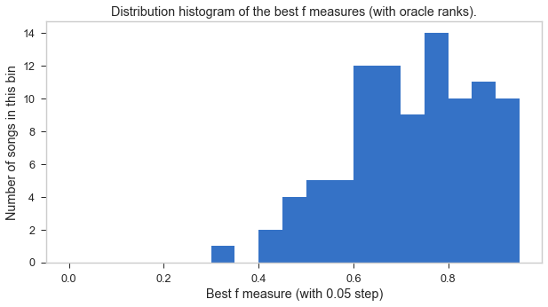

```python
hide.plot_f_mes_histogram(zero_five_eight)
```

# Mixed kernel

This kernel is a trade-off between local and "longer" term similarities.

Concretely, it is a sum of both previous kernels. It is composed of 0 in its diagonal, 2 in the 8 bands surrounding the diagonal, and 1 elsewhere.

It looks like:

[figure not shown]

(or, in a matrix form: $\left[ \begin{matrix} 0 & 2 & 2 & 2& 2 & 1 & 1 & 1\\ 2 & 0 & 2 & 2 & 2& 2 & 1 & 1\\ 2&2 & 0 & 2 & 2 & 2& 2 & 1\\ 2&2&2 & 0 & 2 & 2 & 2& 2\\ 2 & 2 & 2& 2 & 0 & 2&2&2\\ 1 & 2 & 2 & 2& 2 & 0 & 2&2\\ 1 & 1 & 2 & 2 & 2& 2 & 0 & 2\\ 1 & 1 & 1& 2 & 2 & 2& 2 & 0\\ \end{matrix} \right]$ (of size 8 here)).

Mathematically, for a segment ($b_1, b_2$), the associated cost will be $c_{b_1,b_2} = \frac{1}{b_2 - b_1 + 1}(\sum_{i,j = 0, i \ne j}^{n - 1} a_{i + b_1, j + b_1} + \sum_{i,j = 0, 1 \leq |i - j| \leq 4}^{n - 1} a_{i + b_1, j + b_1})$.

It's called mixed kernel as it mixes both previous paradigms.

## Fixed ranks

Below are segmentation results with different ranks values, but each time fixed over the entire RWC Pop dataset.

Results are computed with tolerance of respectively 0.5 seconds and 3 seconds.

```python
annotations_type = "MIREX10"
ranks_rhythm = [12,16,20,24,28,32,36,40,44,48]
ranks_pattern = [12,16,20,24,28,32,36,40,44,48]
zero_five_mixed, three_mixed = hide.compute_ranks_RWC(ranks_rhythm,ranks_pattern, W = "chromas", annotations_type = annotations_type,
                                                  subdivision=96, penalty_weight = 1,penalty_func = "modulo8", convolution_type = "mixed")
```

|  | 0.5 seconds results | True Positives | False Positives | False Negatives | Precision | Recall | F measure |
| --- | --- | --- | --- | --- | --- | --- | --- |
| Rang Q:12 | Rang H:12 | 9.4900 | 10.2300 | 9.3200 | 0.4894 | 0.5109 | 0.4945 |
|  | Rang H:16 | 10.1200 | 9.5800 | 8.6900 | 0.5195 | 0.5428 | 0.5251 |
|  | Rang H:20 | 10.3100 | 9.2500 | 8.5000 | 0.5339 | 0.5516 | 0.5369 |
|  | Rang H:24 | 10.3600 | 9.2300 | 8.4500 | 0.5388 | 0.5539 | 0.5407 |
|  | Rang H:28 | 10.5000 | 9.0400 | 8.3100 | 0.5474 | 0.5620 | 0.5486 |
|  | Rang H:32 | 9.9300 | 9.7600 | 8.8800 | 0.5101 | 0.5329 | 0.5160 |
|  | Rang H:36 | 10.2100 | 9.3400 | 8.6000 | 0.5313 | 0.5474 | 0.5334 |
|  | Rang H:40 | 10.2900 | 9.2400 | 8.5200 | 0.5345 | 0.5510 | 0.5370 |
|  | Rang H:44 | 10.3500 | 9.2600 | 8.4600 | 0.5367 | 0.5536 | 0.5393 |
|  | Rang H:48 | 10.5600 | 9.0100 | 8.2500 | 0.5490 | 0.5640 | 0.5507 |
| Rang Q:16 | Rang H:12 | 10.1300 | 9.7700 | 8.6800 | 0.5188 | 0.5453 | 0.5261 |
|  | Rang H:16 | 10.6200 | 9.0700 | 8.1900 | 0.5512 | 0.5732 | 0.5563 |
|  | Rang H:20 | 10.7000 | 8.9100 | 8.1100 | 0.5544 | 0.5740 | 0.5581 |
|  | Rang H:24 | 10.7500 | 8.8000 | 8.0600 | 0.5609 | 0.5778 | 0.5634 |
|  | Rang H:28 | 10.8700 | 8.8000 | 7.9400 | 0.5648 | 0.5840 | 0.5684 |
|  | Rang H:32 | 10.5900 | 9.2400 | 8.2200 | 0.5450 | 0.5709 | 0.5521 |
|  | Rang H:36 | 10.6300 | 8.9800 | 8.1800 | 0.5503 | 0.5695 | 0.5541 |
|  | Rang H:40 | 10.6300 | 8.9300 | 8.1800 | 0.5529 | 0.5721 | 0.5567 |
|  | Rang H:44 | 10.8200 | 8.7600 | 7.9900 | 0.5625 | 0.5784 | 0.5648 |
|  | Rang H:48 | 10.8400 | 8.8500 | 7.9700 | 0.5607 | 0.5800 | 0.5644 |
| Rang Q:20 | Rang H:12 | 11.0600 | 8.8000 | 7.7500 | 0.5699 | 0.5939 | 0.5764 |
|  | Rang H:16 | 10.8300 | 8.7400 | 7.9800 | 0.5654 | 0.5809 | 0.5673 |
|  | Rang H:20 | 11.0400 | 8.6700 | 7.7700 | 0.5694 | 0.5917 | 0.5743 |
|  | Rang H:24 | 11.2800 | 8.4300 | 7.5300 | 0.5835 | 0.6049 | 0.5879 |
|  | Rang H:28 | 11.2100 | 8.5300 | 7.6000 | 0.5780 | 0.6013 | 0.5835 |
|  | Rang H:32 | 10.7400 | 9.0600 | 8.0700 | 0.5550 | 0.5782 | 0.5612 |
|  | Rang H:36 | 10.9000 | 8.7900 | 7.9100 | 0.5678 | 0.5871 | 0.5717 |
|  | Rang H:40 | 11.2700 | 8.5500 | 7.5400 | 0.5828 | 0.6077 | 0.5891 |
|  | Rang H:44 | 10.9500 | 8.7700 | 7.8600 | 0.5658 | 0.5883 | 0.5712 |
|  | Rang H:48 | 11.1700 | 8.6000 | 7.6400 | 0.5760 | 0.5990 | 0.5816 |

[output cut: 70 more lines]

|  | 3 seconds results | True Positives | False Positives | False Negatives | Precision | Recall | F measure |
| --- | --- | --- | --- | --- | --- | --- | --- |
| Rang Q:12 | Rang H:12 | 13.3400 | 6.3800 | 5.4700 | 0.6885 | 0.7136 | 0.6939 |
|  | Rang H:16 | 13.3800 | 6.3200 | 5.4300 | 0.6901 | 0.7150 | 0.6952 |
|  | Rang H:20 | 13.3600 | 6.2000 | 5.4500 | 0.6954 | 0.7155 | 0.6985 |
|  | Rang H:24 | 13.4200 | 6.1700 | 5.3900 | 0.6980 | 0.7172 | 0.7008 |
|  | Rang H:28 | 13.6700 | 5.8700 | 5.1400 | 0.7148 | 0.7303 | 0.7152 |
|  | Rang H:32 | 13.4900 | 6.2000 | 5.3200 | 0.6970 | 0.7224 | 0.7027 |
|  | Rang H:36 | 13.5000 | 6.0500 | 5.3100 | 0.7048 | 0.7228 | 0.7064 |
|  | Rang H:40 | 13.4700 | 6.0600 | 5.3400 | 0.7041 | 0.7227 | 0.7065 |
|  | Rang H:44 | 13.5400 | 6.0700 | 5.2700 | 0.7038 | 0.7253 | 0.7076 |
|  | Rang H:48 | 13.6300 | 5.9400 | 5.1800 | 0.7125 | 0.7310 | 0.7148 |
| Rang Q:16 | Rang H:12 | 13.5800 | 6.3200 | 5.2300 | 0.6922 | 0.7253 | 0.7012 |
|  | Rang H:16 | 13.5300 | 6.1600 | 5.2800 | 0.7022 | 0.7265 | 0.7072 |
|  | Rang H:20 | 13.7400 | 5.8700 | 5.0700 | 0.7123 | 0.7346 | 0.7162 |
|  | Rang H:24 | 13.6600 | 5.8900 | 5.1500 | 0.7121 | 0.7313 | 0.7146 |
|  | Rang H:28 | 13.9700 | 5.7000 | 4.8400 | 0.7244 | 0.7481 | 0.7292 |
|  | Rang H:32 | 13.9700 | 5.8600 | 4.8400 | 0.7185 | 0.7488 | 0.7262 |
|  | Rang H:36 | 13.6600 | 5.9500 | 5.1500 | 0.7093 | 0.7315 | 0.7134 |
|  | Rang H:40 | 13.6700 | 5.8900 | 5.1400 | 0.7109 | 0.7325 | 0.7147 |
|  | Rang H:44 | 13.7900 | 5.7900 | 5.0200 | 0.7173 | 0.7373 | 0.7204 |
|  | Rang H:48 | 13.8500 | 5.8400 | 4.9600 | 0.7166 | 0.7411 | 0.7216 |
| Rang Q:20 | Rang H:12 | 13.8900 | 5.9700 | 4.9200 | 0.7110 | 0.7423 | 0.7200 |
|  | Rang H:16 | 13.7800 | 5.7900 | 5.0300 | 0.7177 | 0.7362 | 0.7201 |
|  | Rang H:20 | 13.7300 | 5.9800 | 5.0800 | 0.7082 | 0.7334 | 0.7135 |
|  | Rang H:24 | 13.9000 | 5.8100 | 4.9100 | 0.7190 | 0.7433 | 0.7236 |
|  | Rang H:28 | 14.0500 | 5.6900 | 4.7600 | 0.7234 | 0.7519 | 0.7304 |
|  | Rang H:32 | 13.8900 | 5.9100 | 4.9200 | 0.7111 | 0.7414 | 0.7197 |
|  | Rang H:36 | 13.7600 | 5.9300 | 5.0500 | 0.7133 | 0.7384 | 0.7189 |
|  | Rang H:40 | 13.8300 | 5.9900 | 4.9800 | 0.7124 | 0.7419 | 0.7199 |
|  | Rang H:44 | 13.6300 | 6.0900 | 5.1800 | 0.7017 | 0.7303 | 0.7089 |
|  | Rang H:48 | 13.9700 | 5.8000 | 4.8400 | 0.7199 | 0.7485 | 0.7272 |

[output cut: 70 more lines]

## Oracle ranks

In this condition, we only keep the ranks leading to the highest F measure.

In that sense, it's an optimistic upper bound on metrics.

```python
hide.printmd("**A 0.5 secondes:**")
best_chr_zero_five = hide.best_f_one_score_rank(zero_five_mixed)
hide.printmd("**A 3 secondes:**")
best_chr_three = hide.best_f_one_score_rank(three_mixed)
```

**A 0.5 secondes:**

|  | True Positives | False Positives | False Negatives | Precision | Recall | F measure |
| --- | --- | --- | --- | --- | --- | --- |
| Maximizing the f measure on each song: | 14.13 | 5.58 | 4.68 | 0.7311 | 0.7581 | 0.7372 |

**A 3 secondes:**

|  | True Positives | False Positives | False Negatives | Precision | Recall | F measure |
| --- | --- | --- | --- | --- | --- | --- |
| Maximizing the f measure on each song: | 16.37 | 3.24 | 2.44 | 0.846 | 0.874 | 0.8538 |

Below is presented the distribution of the optimal ranks in the "oracle ranks" condition, *i.e.* the distribution of the ranks for $H$ and $Q$ which result in the highest F measure for the different songs.

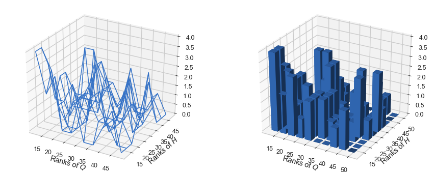

```python
hide.plot_3d_ranks_study(zero_five_mixed, ranks_rhythm, ranks_pattern)
```

Below is shown the distribution histogram of the F measure obtained with the oracle ranks.

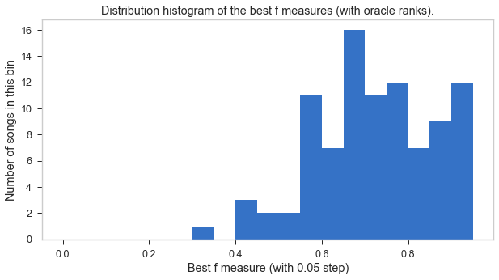

```python
hide.plot_f_mes_histogram(zero_five_mixed)
```

# Conclusion

In conclusion, we considered that the "8 bands kernel" was a reasonnable trade-off between:

- An increase of scores compared to the "full kernel",
- Its simplicity to be explained without all this evaluation context in the paper (especially compared to the "mixed kernel", which need to first introduce both other kernels).

In that sense, we used that kernel in our final experiments, and as the default kernel in the paper.

In future work, if this segmentation technique is still used, it might be interesting to focus on the mixed kernel instead, which seem more promising (notably on its distribution of best ranks).